# 再現コード（Loyalka 2021）

Author

鎌田健太郎

Published

June 10, 2024

## 再現する論文

Loyalka, Prashant, Ou Lydia Liu, Guirong Li, Elena Kardanova, Igor Chirikov, Shangfeng Hu, Ningning Yu, Liping Ma, Fei Guo, Tara Beteille, Namrata Tognatta, Lin Gu, Guangming Ling, Denis Federiakin, Huan Wang, Saurabh Khanna, Ashutosh Bhuradia, Zhaolei Shi & Yanyan Li, 2021, “Skill Levels and Gains in University STEM Education in China, India, Russia and the United States,” *Nature Human Behaviour*, 5(7): 892–904. https://doi.org/10.1038/s41562-021-01062-3

## 著者によるデータ・コード

論文の著者により、Stataコードおよびデータが公開されている。https://osf.io/4t8cu/

websiteより以下のdtaファイルをダウンロードして、`data`フォルダに保存する。

- `college STEM main data - first.dta`
- `college STEM main data - secondB.dta`
- `college STEM main data - third.dta`

## パッケージ読み込み

```r
library(tidyverse)
library(haven)
library(srvyr)
library(marginaleffects)
library(gtsummary)
library(gt)
library(scales)
library(kamaken)

theme_set(
  theme_bw(base_family = 'Hiragino Sans', base_size = 12)+
    theme(
      legend.position = 'bottom',
      axis.text.x = element_text(angle = 45, hjust = 1)
    )
)
```

## Supplementary Table 1

Mean characteristics of first-year undergraduate (bachelor’s degree) computer science and electrical engineering students across countries and types of institutions

- `dad_coll`: Dad college degree
- `mom_coll`: Mom college degree
- `took_cee`: Took entrance exam

```r
data_first <-
  read_dta("data/college STEM main data - first.dta") |>
  as_factor()


df_first <-
  data_first |>
  drop_na(sw_f) |>
  as_survey_design(ids = univcode, weights = sw_f)

# All sample
df_first |>
  filter(stu_merge != 'Endline only' & grade == 1) |>
  select(country_n, age, female, dad_coll, mom_coll, took_cee) |>
  tbl_svysummary(
    by = country_n,
    missing = 'no',
    type = everything() ~ "continuous",
    digits = everything() ~ 3,
    statistic = list(all_continuous() ~ "{mean} [{sd}]")
  )
```

| **Characteristic** | **China**, N = 388,111<sup>1</sup> | **India**, N = 1,256,877<sup>1</sup> | **Russia**, N = 104,018<sup>1</sup> |
| --- | --- | --- | --- |
| age | 19.092 [0.928] | 18.171 [0.936] | 18.559 [1.206] |
| female | 0.289 [0.453] | 0.388 [0.487] | 0.206 [0.404] |
| dad_coll | 0.246 [0.431] | 0.423 [0.494] | 0.832 [0.374] |
| mom_coll | 0.204 [0.403] | 0.342 [0.474] | 0.892 [0.311] |
| took_cee | 0.998 [0.042] | 0.954 [0.210] | 0.846 [0.361] |

<sup>1</sup> Mean [SD]

```r
# Note: 0:non-elite, 1:elite
df_first |>
  filter(stu_merge != 'Endline only' & grade == 1) |>
  select(country_n, elite, age, female, dad_coll, mom_coll, took_cee) |>
  tbl_strata(
    strata = country_n,
    \(x) tbl_svysummary(
      x,
      by = elite,
      missing = 'no',
      type = everything() ~ "continuous",
      digits = everything() ~ 3,
      statistic = list(all_continuous() ~ "{mean} [{sd}]"),
      include = !country_n
    )
  )
```

| **Characteristic** | **China** **0**, N = 294,895<sup>1</sup> | **China** **1**, N = 93,216<sup>1</sup> | **India** **0**, N = 1,202,473<sup>1</sup> | **India** **1**, N = 54,404<sup>1</sup> | **Russia** **0**, N = 79,167<sup>1</sup> | **Russia** **1**, N = 24,851<sup>1</sup> |
| --- | --- | --- | --- | --- | --- | --- |
| age | 19.202 [0.970] | 18.740 [0.667] | 18.156 [0.937] | 18.504 [0.837] | 18.623 [1.276] | 18.358 [0.924] |
| female | 0.286 [0.452] | 0.297 [0.457] | 0.399 [0.490] | 0.142 [0.349] | 0.218 [0.413] | 0.168 [0.374] |
| dad_coll | 0.163 [0.370] | 0.505 [0.500] | 0.413 [0.492] | 0.635 [0.482] | 0.814 [0.389] | 0.885 [0.319] |
| mom_coll | 0.117 [0.322] | 0.471 [0.499] | 0.332 [0.471] | 0.564 [0.496] | 0.881 [0.324] | 0.925 [0.264] |
| took_cee | 0.999 [0.027] | 0.995 [0.071] | 0.952 [0.213] | 0.989 [0.105] | 0.813 [0.390] | 0.951 [0.217] |

<sup>1</sup> Mean [SD]

## Supplementary Table 2

Time spent studying (hours per day)

- `in_college_any2`: Time on college studies
- `out_college_any2`: Time on outside tutoring or mentoring

```r
df_first |>
  filter(grade == 1 & str_detect(testtype2, 'M', negate = TRUE)) |>
  tbl_svysummary(
    by = country_n,
    missing = 'no',
    type = everything() ~ "continuous",
    digits = everything() ~ 2,
    statistic = list(all_continuous() ~ "{mean} [{sd}]"),
    include = c(in_college_any2, out_college_any2)
  )
```

| **Characteristic** | **China**, N = 296,276<sup>1</sup> | **India**, N = 1,115,281<sup>1</sup> | **Russia**, N = 88,296<sup>1</sup> |
| --- | --- | --- | --- |
| in_college_any2 | 7.89 [3.19] | 9.96 [3.97] | 8.77 [3.08] |
| out_college_any2 | 0.43 [0.66] | 0.85 [1.12] | 0.09 [0.34] |

<sup>1</sup> Mean [SD]

```r
df_first |>
  filter(grade == 1 & str_detect(testtype2, 'M', negate = TRUE)) |>
  tbl_strata(
    strata = country_n,
    \(x) tbl_svysummary(
      x,
      by = elite,
      missing = 'no',
      type = everything() ~ "continuous",
      digits = everything() ~ 2,
      statistic = list(all_continuous() ~ "{mean} [{sd}]"),
      include = c(in_college_any2, out_college_any2)
    )
  )
```

| **Characteristic** | **China** **0**, N = 222,693<sup>1</sup> | **China** **1**, N = 73,583<sup>1</sup> | **India** **0**, N = 1,074,421<sup>1</sup> | **India** **1**, N = 40,860<sup>1</sup> | **Russia** **0**, N = 64,889<sup>1</sup> | **Russia** **1**, N = 23,407<sup>1</sup> |
| --- | --- | --- | --- | --- | --- | --- |
| in_college_any2 | 7.71 [3.24] | 8.45 [2.96] | 10.07 [3.98] | 7.67 [2.83] | 8.68 [3.21] | 9.01 [2.67] |
| out_college_any2 | 0.50 [0.68] | 0.23 [0.51] | 0.86 [1.12] | 0.56 [1.01] | 0.10 [0.35] | 0.06 [0.31] |

<sup>1</sup> Mean [SD]

## Figure 1 and Table 1

```r
data_second <-
  read_dta("data/college STEM main data - secondB.dta") |>
  as_factor()

df_second <-
  data_second |>
  drop_na(sw_f) |>
  as_survey_design(ids = univcode, weights = sw_f)
```

```r
res_fig1 <-
  df_second |>
  filter(str_detect(testtype, 'CT') & no_goCT == 0 & grade %in% c(1, 3)) |>
  group_by(country_n, grade, endline) |>
  summarise(
    n = n(),
    mean = survey_mean(z_CT, vartype = 'ci'),
  ) |>
  ungroup() |>
  mutate(
    year = case_when(
      grade == 1 & endline == 0 ~ 'Start of year 1',
      grade == 1 & endline == 1 ~ 'End of year 2',
      grade == 3 & endline == 0 ~ 'Start of year 3',
      grade == 3 & endline == 1 ~ 'End of year 4'
    ) |> fct_relevel('Start of year 1', 'End of year 2', 'Start of year 3', 'End of year 4')
  ) |>
  select(!c(grade, endline))
```

### Figure 1

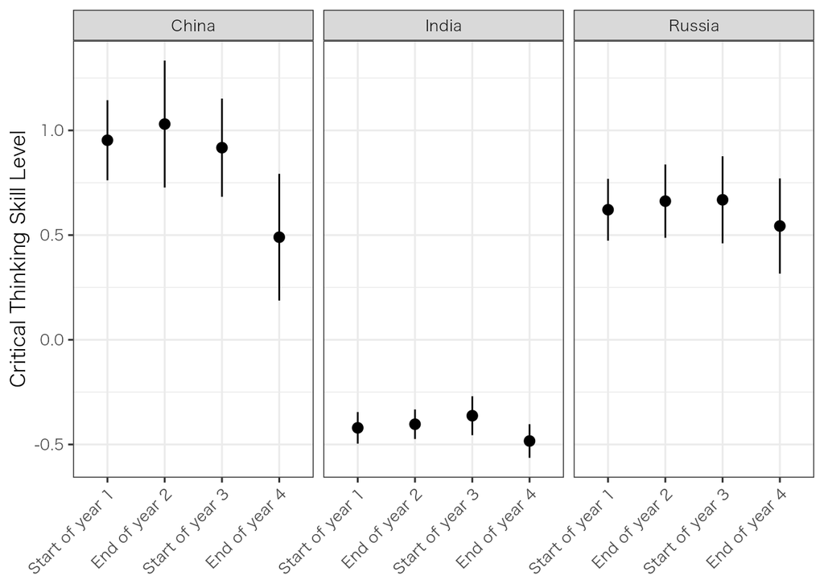

```r
res_fig1 |>
  ggplot(aes(x = year, y = mean, ymin = mean_low, ymax = mean_upp)) +
  geom_pointrange()+
  facet_wrap(vars(country_n))+
  labs(
    x = NULL,
    y = 'Critical Thinking Skill Level'
  )+
  theme(axis.text.x = element_text(angle = 45, hjust = 1))
```

### Table 1

```r
res_fig1 |>
  mutate(
    n = number(n, big.mark = ','),
    mean = number(mean, accuracy = 0.01),
    ci = str_glue('{number(mean_low, accuracy = 0.01)} - {number(mean_upp, accuracy = 0.01)}')
  ) |>
  select(!c(mean_low, mean_upp)) |>
  pivot_longer(cols = c(mean, ci, n), names_to = 'stats') |>
  pivot_wider(names_from = country_n, values_from = value) |>
  gt(groupname_col = 'year', row_group_as_column = TRUE)
```

|  | stats | China | India | Russia |
| --- | --- | --- | --- | --- |
| Start of year 1 | mean | 0.95 | -0.42 | 0.62 |
|  | ci | 0.76 - 1.14 | -0.50 - -0.34 | 0.47 - 0.77 |
|  | n | 1,233 | 1,853 | 614 |
| End of year 2 | mean | 1.03 | -0.40 | 0.66 |
|  | ci | 0.73 - 1.33 | -0.47 - -0.33 | 0.49 - 0.84 |
|  | n | 996 | 2,154 | 512 |
| Start of year 3 | mean | 0.92 | -0.36 | 0.67 |
|  | ci | 0.68 - 1.15 | -0.46 - -0.27 | 0.46 - 0.88 |
|  | n | 992 | 2,202 | 446 |
| End of year 4 | mean | 0.49 | -0.48 | 0.54 |
|  | ci | 0.19 - 0.79 | -0.56 - -0.40 | 0.32 - 0.77 |
|  | n | 796 | 2,153 | 430 |

## Figure 2 and Table 2

```r
res_fig2_math <-
  df_second |>
  filter(str_detect(testtype, 'M') & no_gomath == 0 & grade == 1) |>
  group_by(country_n, grade, endline) |>
  summarise(
    n = n(),
    mean = survey_mean(z_math, vartype = 'ci'),
  ) |>
  ungroup()

res_fig2_phys <-
  df_second |>
  filter(str_detect(testtype, 'P') & no_gophys == 0 & grade == 1) |>
  group_by(country_n, grade, endline) |>
  summarise(
    n = n(),
    mean = survey_mean(z_phys, vartype = 'ci'),
  ) |>
  ungroup()

res_fig2 <-
  bind_rows(
    `Math Skill Level` = res_fig2_math,
    `Physics Skill Level` = res_fig2_phys,
    .id = 'skill'
  ) |>
  mutate(
    year = case_when(
      grade == 1 & endline == 0 ~ 'Start of year 1',
      grade == 1 & endline == 1 ~ 'End of year 2',
      grade == 3 & endline == 0 ~ 'Start of year 3',
      grade == 3 & endline == 1 ~ 'End of year 4'
    ) |> fct_relevel('Start of year 1', 'End of year 2', 'Start of year 3', 'End of year 4')
  ) |>
  select(!c(grade, endline))
```

### Figure 2

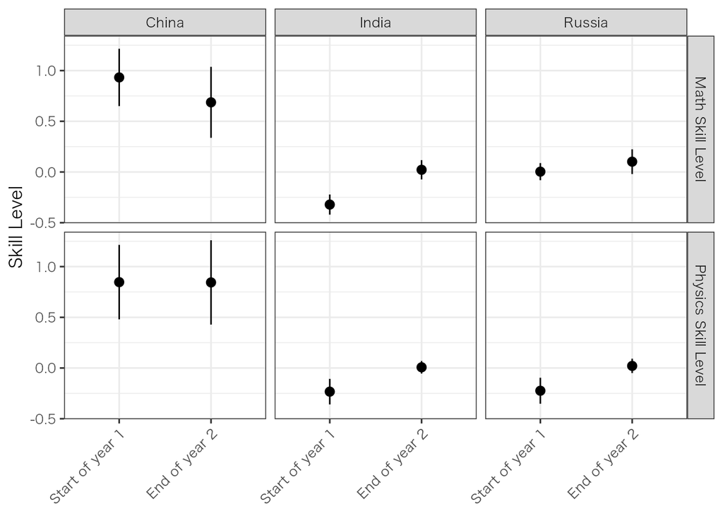

```r
res_fig2 |>
  ggplot(aes(x = year, y = mean, ymin = mean_low, ymax = mean_upp)) +
  geom_pointrange()+
  facet_grid(rows = vars(skill), cols = vars(country_n))+
  labs(
    x = NULL,
    y = 'Skill Level'
  )
```

### Table 2

```r
res_fig2 |>
  mutate(
    n = number(n, big.mark = ','),
    mean = number(mean, accuracy = 0.001),
    ci = str_glue('{number(mean_low, accuracy = 0.001)} - {number(mean_upp, accuracy = 0.001)}')
  ) |>
  select(!c(mean_low, mean_upp)) |>
  pivot_longer(cols = c(mean, ci, n), names_to = 'stats') |>
  pivot_wider(names_from = country_n, values_from = value) |>
  gt(groupname_col = 'skill', row_group_as_column = TRUE)
```

|  | year | stats | China | India | Russia |
| --- | --- | --- | --- | --- | --- |
| Math Skill Level | Start of year 1 | mean | 0.933 | -0.321 | 0.004 |
|  | Start of year 1 | ci | 0.650 - 1.215 | -0.421 - -0.222 | -0.081 - 0.088 |
|  | Start of year 1 | n | 2,435 | 3,742 | 1,132 |
|  | End of year 2 | mean | 0.687 | 0.022 | 0.102 |
|  | End of year 2 | ci | 0.337 - 1.037 | -0.073 - 0.117 | -0.020 - 0.224 |
|  | End of year 2 | n | 1,969 | 4,485 | 966 |
| Physics Skill Level | Start of year 1 | mean | 0.847 | -0.233 | -0.224 |
|  | Start of year 1 | ci | 0.480 - 1.214 | -0.359 - -0.107 | -0.352 - -0.096 |
|  | Start of year 1 | n | 2,423 | 3,916 | 722 |
|  | End of year 2 | mean | 0.844 | 0.007 | 0.021 |
|  | End of year 2 | ci | 0.428 - 1.260 | -0.055 - 0.069 | -0.050 - 0.092 |
|  | End of year 2 | n | 1,983 | 4,510 | 627 |

## Table 3

Comparing Critical Thinking and Academic Skill Levels and Gains Across Elite and Non-Elite Institutions (China, India, Russia, Grades 1 and 3)

```r
res_tab3_CT <-
  df_second |>
  filter(str_detect(testtype, 'CT') & no_goCT == 0 & grade %in% c(1, 3)) |>
  group_by(country_n, grade, endline, elite) |>
  summarise(
    n = n(),
    mean = survey_mean(z_CT, vartype = 'ci'),
  ) |>
  ungroup()

res_tab3_math <-
  df_second |>
  filter(str_detect(testtype, 'M') & no_gomath == 0 & grade %in% c(1, 3)) |>
  group_by(country_n, grade, endline, elite) |>
  summarise(
    n = n(),
    mean = survey_mean(z_math, vartype = 'ci'),
  ) |>
  ungroup()

res_tab3_phys <-
  df_second |>
  filter(str_detect(testtype, 'P') & no_gophys == 0 & grade %in% c(1, 3)) |>
  group_by(country_n, grade, endline, elite) |>
  summarise(
    n = n(),
    mean = survey_mean(z_phys, vartype = 'ci'),
  ) |>
  ungroup()


res_tab3 <-
  bind_rows(
    `Critical Thinking` = res_tab3_CT,
    `Math Skill Level` = res_tab3_math,
    `Physics Skill Level` = res_tab3_phys,
    .id = 'skill'
  ) |>
  mutate(
    year = case_when(
      grade == 1 & endline == 0 ~ 'Start of year 1',
      grade == 1 & endline == 1 ~ 'End of year 2',
      grade == 3 & endline == 0 ~ 'Start of year 3',
      grade == 3 & endline == 1 ~ 'End of year 4'
    ) |> fct_relevel('Start of year 1', 'End of year 2', 'Start of year 3', 'End of year 4'),
    elite = case_when(
      elite == 0 ~ 'Non-Elite',
      elite == 1 ~ 'Elite'
    ) |> fct_relevel('Non-Elite', 'Elite')
  ) |>
  select(!c(grade, endline))
```

```r
res_tab3 |>
  mutate(
    mean = number(mean, accuracy = 0.001),
    ci = str_glue('{number(mean_low, accuracy = 0.001)} - {number(mean_upp, accuracy = 0.001)}'),
    neko = str_glue('{country_n}_{elite}')
  ) |>
  pivot_longer(cols = c(mean, ci), names_to = 'stats') |>
  select(skill, neko, year, stats, value) |>
  pivot_wider(names_from = neko, values_from = value) |>
  gt(groupname_col = 'skill', row_group_as_column = TRUE) |>
  tab_spanner_delim(delim = '_')
```

|  | year | stats | China Non-Elite | China Elite | India Non-Elite | India Elite | Russia Non-Elite | Russia Elite |
| --- | --- | --- | --- | --- | --- | --- | --- | --- |
| Critical Thinking | Start of year 1 | mean | 0.741 | 1.612 | -0.462 | 0.509 | 0.544 | 0.833 |
|  | Start of year 1 | ci | 0.663 - 0.819 | 1.285 - 1.938 | -0.530 - -0.393 | 0.335 - 0.683 | 0.388 - 0.700 | 0.575 - 1.092 |
|  | End of year 2 | mean | 0.735 | 1.905 | -0.438 | 0.542 | 0.608 | 0.810 |
|  | End of year 2 | ci | 0.553 - 0.916 | 1.308 - 2.502 | -0.503 - -0.374 | 0.427 - 0.657 | 0.432 - 0.785 | 0.342 - 1.279 |
|  | Start of year 3 | mean | 0.665 | 1.602 | -0.406 | 0.596 | 0.651 | 0.730 |
|  | Start of year 3 | ci | 0.498 - 0.832 | 1.285 - 1.920 | -0.494 - -0.318 | 0.413 - 0.779 | 0.426 - 0.876 | 0.189 - 1.271 |
|  | End of year 4 | mean | 0.234 | 1.339 | -0.519 | 0.232 | 0.491 | 0.767 |
|  | End of year 4 | ci | 0.111 - 0.357 | 0.720 - 1.957 | -0.596 - -0.441 | 0.039 - 0.425 | 0.255 - 0.726 | 0.108 - 1.425 |
| Math Skill Level | Start of year 1 | mean | 0.641 | 1.850 | -0.366 | 0.851 | -0.024 | 0.111 |
|  | Start of year 1 | ci | 0.515 - 0.768 | 1.354 - 2.346 | -0.457 - -0.275 | 0.731 - 0.972 | -0.110 - 0.063 | -0.125 - 0.346 |
|  | End of year 2 | mean | 0.342 | 1.767 | -0.021 | 1.166 | 0.050 | 0.327 |
|  | End of year 2 | ci | 0.226 - 0.457 | 1.123 - 2.411 | -0.109 - 0.067 | 1.021 - 1.311 | -0.080 - 0.180 | 0.103 - 0.550 |
|  | Start of year 3 | mean | 0.681 | 1.799 | 0.012 | 1.133 | 0.076 | 0.312 |
|  | Start of year 3 | ci | 0.549 - 0.814 | 1.275 - 2.323 | -0.085 - 0.109 | 1.028 - 1.239 | -0.059 - 0.211 | 0.142 - 0.482 |
| Physics Skill Level | Start of year 1 | mean | 0.504 | 1.936 | -0.301 | 1.419 | -0.288 | -0.029 |
|  | Start of year 1 | ci | 0.409 - 0.598 | 1.097 - 2.775 | -0.408 - -0.195 | 1.207 - 1.630 | -0.425 - -0.150 | -0.245 - 0.187 |
|  | End of year 2 | mean | 0.455 | 2.089 | -0.029 | 1.008 | 0.017 | 0.036 |
|  | End of year 2 | ci | 0.327 - 0.583 | 1.194 - 2.983 | -0.080 - 0.021 | 0.885 - 1.131 | -0.050 - 0.084 | -0.203 - 0.276 |
|  | Start of year 3 | mean | 0.556 | 1.707 | -0.056 | 0.828 | 0.106 | 0.361 |
|  | Start of year 3 | ci | 0.425 - 0.687 | 1.156 - 2.258 | -0.107 - -0.005 | 0.687 - 0.970 | -0.024 - 0.236 | 0.236 - 0.486 |

図にするとこんな感じ

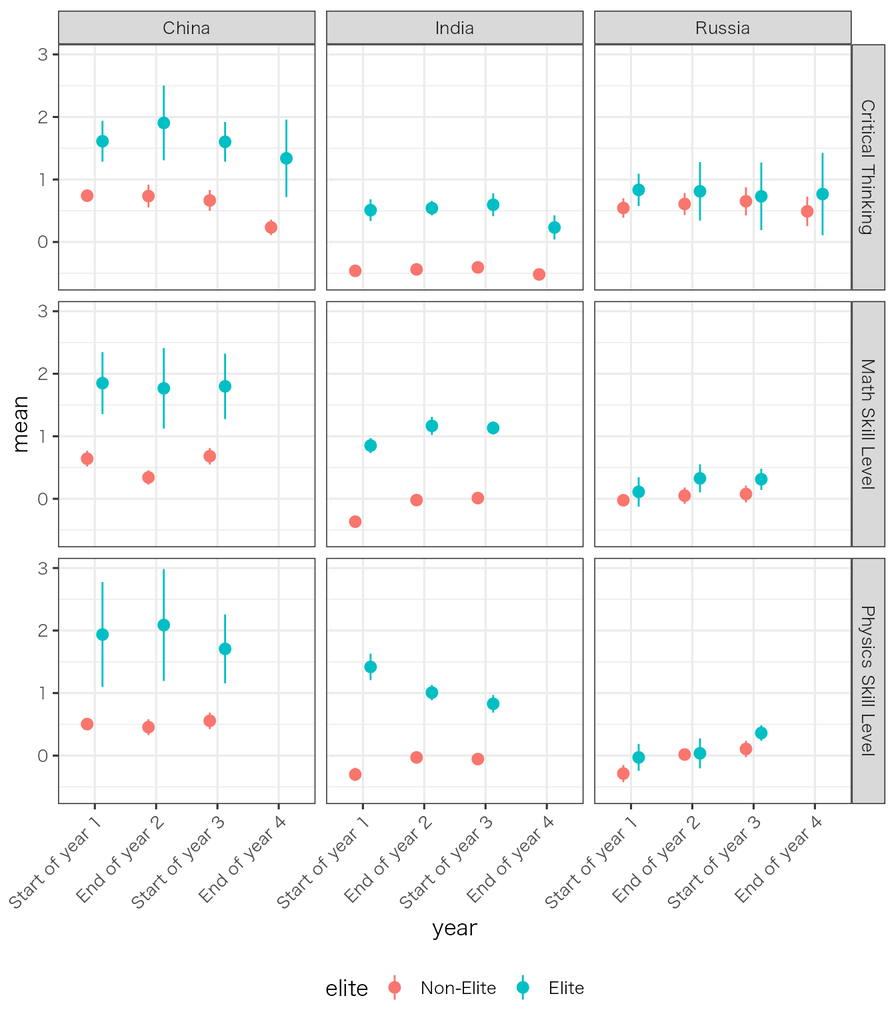

```r
res_tab3 |>
  ggplot(aes(year, mean, ymin = mean_low, ymax = mean_upp, color = elite)) +
  geom_pointrange(position = position_dodge(width = 0.5))+
  facet_grid(cols = vars(country_n), rows = vars(skill))
```

## Table 4

Comparing Critical Thinking and Academic Skill Levels and Gains by Gender (China, India, Russia)

```r
res_tab4_CT <-
  df_second |>
  filter(str_detect(testtype, 'CT') & no_goCT == 0 & grade %in% c(1, 3) & !is.na(female)) |>
  group_by(country_n, grade, endline, female) |>
  summarise(
    n = n(),
    mean = survey_mean(z_CT, vartype = 'ci'),
  ) |>
  ungroup()

res_tab4_math <-
  df_second |>
  filter(str_detect(testtype, 'M') & no_gomath == 0 & grade %in% c(1, 3) & !is.na(female)) |>
  group_by(country_n, grade, endline, female) |>
  summarise(
    n = n(),
    mean = survey_mean(z_math, vartype = 'ci'),
  ) |>
  ungroup()

res_tab4_phys <-
  df_second |>
  filter(str_detect(testtype, 'P') & no_gophys == 0 & grade %in% c(1, 3) & !is.na(female)) |>
  group_by(country_n, grade, endline, female) |>
  summarise(
    n = n(),
    mean = survey_mean(z_phys, vartype = 'ci'),
  ) |>
  ungroup()


res_tab4 <-
  bind_rows(
    `Critical Thinking` = res_tab4_CT,
    `Math Skill Level` = res_tab4_math,
    `Physics Skill Level` = res_tab4_phys,
    .id = 'skill'
  ) |>
  mutate(
    year = case_when(
      grade == 1 & endline == 0 ~ 'Start of year 1',
      grade == 1 & endline == 1 ~ 'End of year 2',
      grade == 3 & endline == 0 ~ 'Start of year 3',
      grade == 3 & endline == 1 ~ 'End of year 4'
    ) |> fct_relevel('Start of year 1', 'End of year 2', 'Start of year 3', 'End of year 4'),
    female = case_when(
      female == 0 ~ 'Male',
      female == 1 ~ 'Female'
    ) |> fct_relevel('Male', 'Female')
  ) |>
  select(!c(grade, endline))
```

```r
res_tab4 |>
  mutate(
    mean = number(mean, accuracy = 0.001),
    ci = str_glue('{number(mean_low, accuracy = 0.001)} - {number(mean_upp, accuracy = 0.001)}'),
    neko = str_glue('{country_n}_{female}')
  ) |>
  pivot_longer(cols = c(mean, ci), names_to = 'stats') |>
  select(skill, neko, year, stats, value) |>
  pivot_wider(names_from = neko, values_from = value) |>
  gt(groupname_col = 'skill', row_group_as_column = TRUE) |>
  tab_spanner_delim(delim = '_')
```

|  | year | stats | China Male | China Female | India Male | India Female | Russia Male | Russia Female |
| --- | --- | --- | --- | --- | --- | --- | --- | --- |
| Critical Thinking | Start of year 1 | mean | 0.986 | 0.871 | -0.401 | -0.451 | 0.626 | 0.594 |
|  | Start of year 1 | ci | 0.774 - 1.199 | 0.701 - 1.041 | -0.488 - -0.315 | -0.533 - -0.368 | 0.479 - 0.774 | 0.331 - 0.858 |
|  | End of year 2 | mean | 1.039 | 1.009 | -0.386 | -0.429 | 0.652 | 0.700 |
|  | End of year 2 | ci | 0.762 - 1.316 | 0.601 - 1.416 | -0.470 - -0.302 | -0.505 - -0.354 | 0.496 - 0.808 | 0.294 - 1.106 |
|  | Start of year 3 | mean | 1.006 | 0.700 | -0.335 | -0.401 | 0.604 | 0.881 |
|  | Start of year 3 | ci | 0.721 - 1.291 | 0.536 - 0.864 | -0.448 - -0.222 | -0.478 - -0.325 | 0.387 - 0.821 | 0.534 - 1.228 |
|  | End of year 4 | mean | 0.588 | 0.226 | -0.474 | -0.496 | 0.498 | 0.687 |
|  | End of year 4 | ci | 0.246 - 0.930 | 0.010 - 0.442 | -0.573 - -0.374 | -0.569 - -0.424 | 0.256 - 0.741 | 0.329 - 1.045 |
| Math Skill Level | Start of year 1 | mean | 0.978 | 0.827 | -0.280 | -0.384 | 0.006 | -0.004 |
|  | Start of year 1 | ci | 0.655 - 1.301 | 0.623 - 1.031 | -0.391 - -0.169 | -0.484 - -0.285 | -0.083 - 0.095 | -0.113 - 0.104 |
|  | End of year 2 | mean | 0.681 | 0.704 | 0.021 | 0.023 | 0.075 | 0.196 |
|  | End of year 2 | ci | 0.283 - 1.078 | 0.451 - 0.956 | -0.087 - 0.129 | -0.079 - 0.126 | -0.044 - 0.193 | 0.050 - 0.342 |
|  | Start of year 3 | mean | 0.973 | 0.929 | 0.092 | 0.010 | 0.157 | 0.096 |
|  | Start of year 3 | ci | 0.671 - 1.276 | 0.743 - 1.115 | -0.033 - 0.216 | -0.087 - 0.107 | 0.031 - 0.283 | -0.040 - 0.233 |
| Physics Skill Level | Start of year 1 | mean | 0.938 | 0.630 | -0.189 | -0.300 | -0.206 | -0.295 |
|  | Start of year 1 | ci | 0.538 - 1.338 | 0.337 - 0.924 | -0.353 - -0.026 | -0.376 - -0.224 | -0.310 - -0.102 | -0.591 - 0.001 |
|  | End of year 2 | mean | 0.905 | 0.689 | 0.033 | -0.030 | 0.016 | 0.039 |
|  | End of year 2 | ci | 0.448 - 1.362 | 0.377 - 1.001 | -0.043 - 0.110 | -0.086 - 0.027 | -0.066 - 0.099 | -0.045 - 0.123 |
|  | Start of year 3 | mean | 0.904 | 0.684 | 0.020 | -0.077 | 0.232 | 0.047 |
|  | Start of year 3 | ci | 0.607 - 1.201 | 0.450 - 0.918 | -0.056 - 0.096 | -0.129 - -0.025 | 0.080 - 0.384 | -0.106 - 0.201 |

図にするとこんな感じ

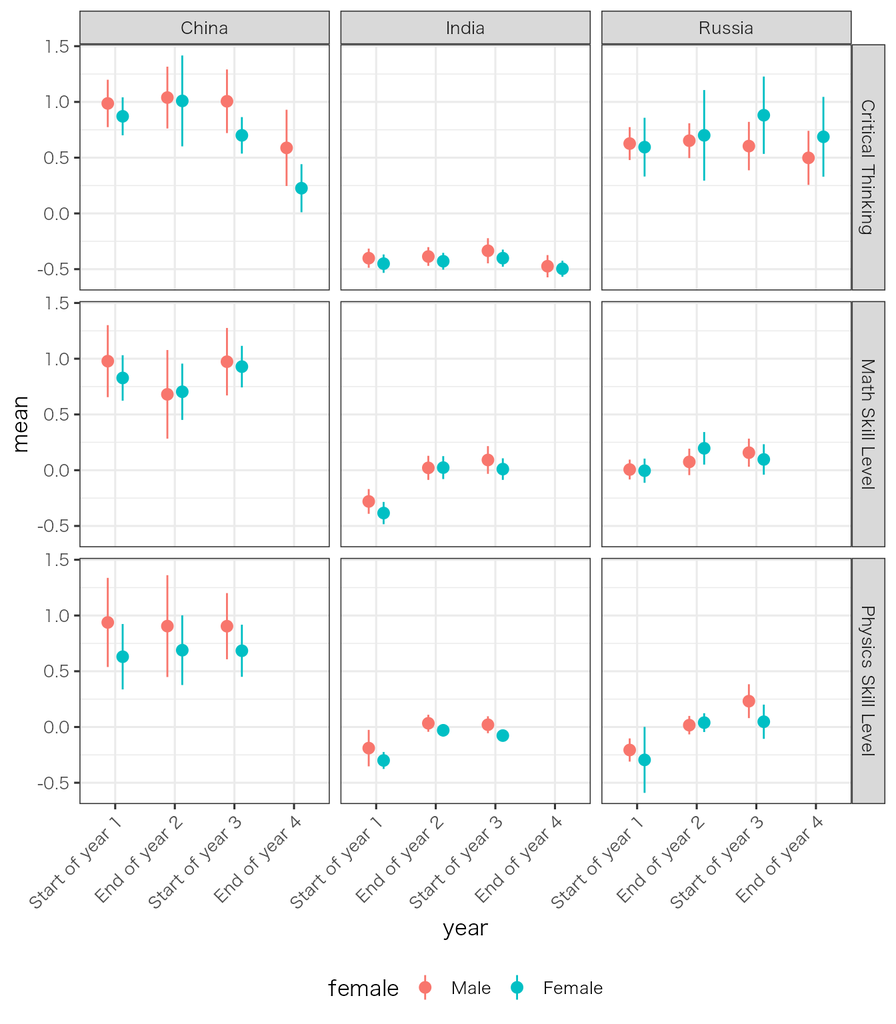

```r
res_tab4 |>
  ggplot(aes(year, mean, ymin = mean_low, ymax = mean_upp, color = female)) +
  geom_pointrange(position = position_dodge(width = 0.5))+
  facet_grid(cols = vars(country_n), rows = vars(skill))
```

# 遊んでみる

```r
data_first |>
  glimpse()
data_second |>
  glimpse()


data_first |>
  select(stu_merge:sw_f, female:mom_coll) |>
  count(pick(everything()))
data_second |>
  select(stu_merge:grade, testtype2 = testtype, country:elite, sw_f, female:mom_coll, strata) |>
  count(pick(everything()), sort = TRUE)
```

## 学習時間の分布

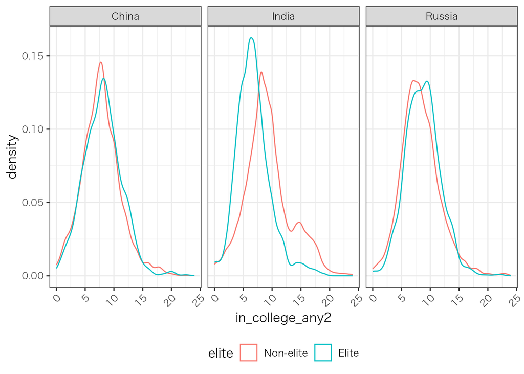

```r
data_first |>
  drop_na(sw_f) |>
  mutate(
    elite = case_when(
      elite == 0 ~ 'Non-elite',
      elite == 1 ~ 'Elite'
    ) |> fct_relevel('Non-elite', 'Elite'),
  ) |>
  ggplot(aes(in_college_any2, color = elite, weight = sw_f))+
  geom_density()+
  facet_wrap(vars(country_n))
```

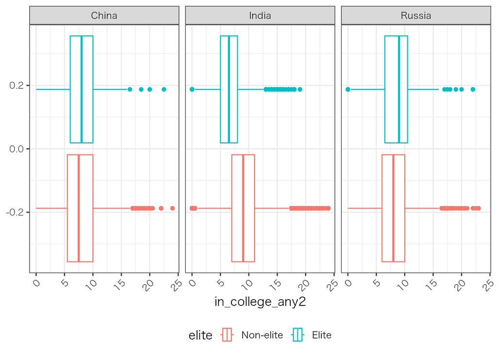

```r
data_first |>
  drop_na(sw_f) |>
  mutate(
    elite = case_when(
      elite == 0 ~ 'Non-elite',
      elite == 1 ~ 'Elite'
    ) |> fct_relevel('Non-elite', 'Elite'),
  ) |>
  ggplot(aes(in_college_any2, color = elite, weight = sw_f))+
  geom_boxplot()+
  facet_wrap(vars(country_n))
```

## Critical Thinkingの予測（Average Marginal Effects）

2年終了時のCritical Thinkingのスコアを予測する回帰モデル

```r
res_pred_CT <-
  df_second |>
  filter(str_detect(testtype, 'CT') & no_goCT == 0 & grade %in% 1 & endline == 1) |>
  survey::svyglm(
    z_CT ~ (elite + female + dad_coll + mom_coll + ses1 + tutoring_hours + paid_work_hours + entrepreneur_yn + commserve_yn + internship_yn)*country_n,
    design = _, family = gaussian
  )

avg_slopes(
  res_pred_CT, wts = res_pred_CT$weights,
) |>
  as_tibble() |>
  select(term:std.error, conf.low, conf.high) |>
  gt() |>
  fmt_number(decimals = 3)
```

| term | contrast | estimate | std.error | conf.low | conf.high |
| --- | --- | --- | --- | --- | --- |
| commserve_yn | mean(1) - mean(0) | −0.100 | 0.039 | −0.175 | −0.024 |
| country_n | mean(India) - mean(China) | −1.150 | 0.099 | −1.345 | −0.955 |
| country_n | mean(Russia) - mean(China) | −0.808 | 0.273 | −1.344 | −0.272 |
| dad_coll | mean(1) - mean(0) | 0.203 | 0.065 | 0.075 | 0.331 |
| elite | mean(1) - mean(0) | 0.762 | 0.065 | 0.634 | 0.889 |
| entrepreneur_yn | mean(1) - mean(0) | −0.059 | 0.050 | −0.157 | 0.038 |
| female | mean(1) - mean(0) | −0.039 | 0.036 | −0.110 | 0.031 |
| internship_yn | mean(1) - mean(0) | −0.162 | 0.035 | −0.230 | −0.094 |
| mom_coll | mean(1) - mean(0) | 0.046 | 0.051 | −0.054 | 0.146 |
| paid_work_hours | mean(1) - mean(0) | −0.130 | 0.082 | −0.291 | 0.031 |
| ses1 | mean(dY/dX) | 0.087 | 0.015 | 0.058 | 0.116 |
| tutoring_hours | mean(dY/dX) | −0.064 | 0.024 | −0.111 | −0.017 |